# Habitat selection models in R

Load libraries

```r
library(chron)
library(rgdal)
library(maptools)
library(raster)
library(rgdal)
library(shapefiles)
library(rgeos)
library(adehabitatHR)
library(spatstat)
library(lattice)
library(ResourceSelection)
library(splancs)  # for csr to generate random points
library(KernSmooth)
library(nlme)
library(sp)
```

First, delete everything in working memory.

```r
   #rm(list=ls(all=TRUE))
```

Read in data, clean it up, combine packs and remove those “without home ranges” according to Steve

```r
###orig wolf data
wolf<-read.csv("E:/Moose/Data/Voyageurs_National_Park/AllVNPWolf_MD102815.csv",header=TRUE)
#table(as.factor(wolf$WOLFID),wolf$WOLFID)

###2015 Lotek Data
lowolf<-read.csv("E:/Moose/Data/Voyageurs_National_Park/VNPwolfdataMark112515/VNPwolfdataMark112515/Lotek111715.csv",header=TRUE)
###remove misses
lowolfC<-lowolf[lowolf$Latitude!=0,]
#table(as.factor(lowolfC$WOLFID),lowolfC$WOLFID)

###2015 Lotek Data
vecwolf<-read.csv("E:/Moose/Data/Voyageurs_National_Park/VNPwolfdataMark112515/VNPwolfdataMark112515/Vect111715.csv",header=TRUE)
###remove misses
vecwolfC<-vecwolf[vecwolf$Latitude!=0,]
#table(as.factor(vecwolfC$WOLFID),vecwolfC$WOLFID)

###subset orig data to just the ones not included in 2015 updated data
### set up all the attributes so they can all be combined with the same names
wolfO<-wolf
wolfOrigC<-wolfO[wolfO$WOLFID=="V003"|wolfO$WOLFID=="V007"|wolfO$WOLFID=="V008"|wolfO$WOLFID=="V010"|wolfO$WOLFID=="V011"|wolfO$WOLFID=="V012",]
unique(wolfOrigC$WOLFID)
```

```
## [1] V003 V007 V008 V010 V011 V012
## 20 Levels: V003 V007 V008 V009 V010 V011 V012 V013 V014 V023 V024 ... V2220
```

```r
head(wolfOrigC)
```

```
##   OBJECTID WOLFID Latitude Longitude Altitude Temp_C       Date     Time
## 1        1   V003 48.46743 -92.94910   631601      0  10/9/2012 04:00:00
## 2        2   V003 48.46915 -92.94858   631601      0  10/9/2012 08:00:00
## 3        3   V003 48.47919 -92.96120   631601      0 10/10/2012 04:01:00
## 4        4   V003 48.48434 -92.97056   631601      0 10/10/2012 08:00:00
## 5        5   V003 48.47704 -92.95648   631601      0 10/10/2012 12:00:00
## 6        6   V003 48.46657 -92.94215   631601      0 10/11/2012 08:00:00
##   Dem10_VNP_ Asp_VNP_st Slp_VNP_st lulc_vnp_a  UTM_x   UTM_y   UTMX  UTMX2
## 1    350.219    171.027    4.58231          5 503762 5368257 503762 503762
## 2    339.099    180.000    2.86241          2 503800 5368447 503800 503800
## 3    341.963    239.036    4.16874          5 502867 5369563 502867 502867
## 4    349.443    286.440   27.92370          5 502176 5370135 502176 502176
## 5    353.928    280.713    8.91709          5 503216 5369325 503216 503216
## 6    361.987    186.582   12.30380          5 504277 5368162 504277 504277
```

```r
wolfvar<-c("OBJECTID","WOLFID","Latitude","Longitude","Altitude","Date","Time","Temp_C")
wolfOrigC<-wolfOrigC[(wolfvar)]
head(wolfOrigC)
```

```
##   OBJECTID WOLFID Latitude Longitude Altitude       Date     Time Temp_C
## 1        1   V003 48.46743 -92.94910   631601  10/9/2012 04:00:00      0
## 2        2   V003 48.46915 -92.94858   631601  10/9/2012 08:00:00      0
## 3        3   V003 48.47919 -92.96120   631601 10/10/2012 04:01:00      0
## 4        4   V003 48.48434 -92.97056   631601 10/10/2012 08:00:00      0
## 5        5   V003 48.47704 -92.95648   631601 10/10/2012 12:00:00      0
## 6        6   V003 48.46657 -92.94215   631601 10/11/2012 08:00:00      0
```

```r
wolfOrigC$Time <- chron(times=as.character(wolfOrigC$Time))
wolfOrigC$Date<- as.POSIXlt(wolfOrigC$Date, format= "%m/%d/%Y")
wolfOrigC$dtm <- as.factor(paste(wolfOrigC$Date, wolfOrigC$Time, sep = " "))
wolfOrigC$dtPm<-strptime(wolfOrigC$dtm, "%Y-%m-%d %H:%M:%S")
str(wolfOrigC$dtPm)
```

```
##  POSIXlt[1:8655], format: "2012-10-09 04:00:00" "2012-10-09 08:00:00" ...
```

```r
wolfOrigC$dtPm <- as.POSIXct(wolfOrigC$dtPm)



###keep all LOtek - change blanks to "V047, and set up attribute names
lowolfC$WOLFID<-as.character(lowolfC$WOLFID)
lowolfC$WOLFID[lowolfC$WOLFID==""] <- "V047"
lowolfC2<-lowolfC
head(lowolfC2)
```

```
##   OBJECTID DeviceName WOLFID DeviceID    DateTimeGMT    DateTimeLoc
## 1        1  Ray South   V014    33078 8/5/2013 18:00 8/5/2013 18:00
## 2        2  Ray South   V014    33078 8/6/2013 00:01 8/6/2013 00:01
## 3        3  Ray South   V014    33078 8/6/2013 06:01 8/6/2013 06:01
## 4        4  Ray South   V014    33078 8/6/2013 12:02 8/6/2013 12:02
## 5        5  Ray South   V014    33078 8/6/2013 18:00 8/6/2013 18:00
## 6        6  Ray South   V014    33078 8/7/2013 00:00 8/7/2013 00:00
##   Latitude Longitude Altitude FixStatus DOP Temp Main Back
## 1 48.48560 -93.23740   307.52  3D-V Fix 5.2   25 3.52 3.60
## 2 48.48665 -93.24601   307.43  3D-V Fix 1.6   28 3.52 3.60
## 3 48.48663 -93.24589   307.67    2D Fix 2.2   18 3.52 3.52
## 4 48.46321 -93.24720   307.87    2D Fix 3.6   17 3.52 3.52
## 5 48.44337 -93.21282   322.39  3D-V Fix 1.8   21 3.52 3.52
## 6 48.44095 -93.21749   328.62  3D-V Fix 5.4   20 3.52 3.60
```

```r
###remove locations with a ton of error
lowolfC3<-lowolfC2[c(lowolfC2$DOP<15),]
lovars<-c("OBJECTID","WOLFID","Latitude","Longitude","Altitude","DateTimeGMT","Temp")
lowolfC3<-lowolfC3[(lovars)]
head(lowolfC3)
```

```
##   OBJECTID WOLFID Latitude Longitude Altitude    DateTimeGMT Temp
## 1        1   V014 48.48560 -93.23740   307.52 8/5/2013 18:00   25
## 2        2   V014 48.48665 -93.24601   307.43 8/6/2013 00:01   28
## 3        3   V014 48.48663 -93.24589   307.67 8/6/2013 06:01   18
## 4        4   V014 48.46321 -93.24720   307.87 8/6/2013 12:02   17
## 5        5   V014 48.44337 -93.21282   322.39 8/6/2013 18:00   21
## 6        6   V014 48.44095 -93.21749   328.62 8/7/2013 00:00   20
```

```r
lowolfC3$DateTimeGMT<- as.POSIXlt(lowolfC3$DateTimeGMT, format= "%m/%d/%Y %H:%M")
lowolfC3$dtPm <- as.POSIXct(lowolfC3$DateTimeGMT, tz="GMT")
lowolfC3$dtPm<-format(lowolfC3$dtPm, tz="America/Chicago",usetz=TRUE)

### Vectronic data - do the same as above - different attribute names
###remove locations with a ton of error
vecwolfC2<-vecwolfC[c(vecwolfC$DOP<15),]
vecvars<-c("OBJECTID","WOLFID","Latitude","Longitude","Height","UTC_Date","UTC_Time","TempC")
vecwolfC3<-vecwolfC2[(vecvars)]
head(vecwolfC3)
```

```
##   OBJECTID WOLFID Latitude Longitude Height       UTC_Date    UTC_Time
## 1        2   V026 48.30329 -92.83229 377.22 8/4/2014 00:00 06:00:51 PM
## 3        4   V026 48.30306 -92.83287 355.98 8/5/2014 00:00 06:00:36 PM
## 4        5   V026 48.31247 -92.85251 431.64 8/6/2014 00:00 06:01:03 AM
## 5        6   V026 48.31266 -92.85469 421.49 8/7/2014 00:00 06:01:11 AM
## 6        7   V026 48.34393 -92.90764 329.82 8/7/2014 00:00 06:02:03 PM
## 7        8   V026 48.35592 -92.83743 401.44 8/8/2014 00:00 06:01:04 AM
##   TempC
## 1    24
## 3    31
## 4    19
## 5    29
## 6    31
## 7    20
```

```r
#vecwolfC3$UTC_Time <- chron(times=as.character(vecwolfC3$UTC_Time))
vecwolfC3$UTC_Date<- as.POSIXlt(vecwolfC3$UTC_Date, format= "%m/%d/%Y ")
vecwolfC3$dtm <- as.factor(paste(vecwolfC3$UTC_Date, vecwolfC3$UTC_Time, sep = " "))
vecwolfC3$dtPm<-strptime(vecwolfC3$dtm, "%Y-%m-%d %H:%M:%S")
vecwolfC3$dtPm <- as.POSIXct(vecwolfC3$dtPm, tz="GMT")
vecwolfC3$dtPm<-format(vecwolfC3$dtPm, tz="America/Chicago",usetz=TRUE)
head(vecwolfC3)
```

```
##   OBJECTID WOLFID Latitude Longitude Height   UTC_Date    UTC_Time TempC
## 1        2   V026 48.30329 -92.83229 377.22 2014-08-04 06:00:51 PM    24
## 3        4   V026 48.30306 -92.83287 355.98 2014-08-05 06:00:36 PM    31
## 4        5   V026 48.31247 -92.85251 431.64 2014-08-06 06:01:03 AM    19
## 5        6   V026 48.31266 -92.85469 421.49 2014-08-07 06:01:11 AM    29
## 6        7   V026 48.34393 -92.90764 329.82 2014-08-07 06:02:03 PM    31
## 7        8   V026 48.35592 -92.83743 401.44 2014-08-08 06:01:04 AM    20
##                      dtm                    dtPm
## 1 2014-08-04 06:00:51 PM 2014-08-04 01:00:51 CDT
## 3 2014-08-05 06:00:36 PM 2014-08-05 01:00:36 CDT
## 4 2014-08-06 06:01:03 AM 2014-08-06 01:01:03 CDT
## 5 2014-08-07 06:01:11 AM 2014-08-07 01:01:11 CDT
## 6 2014-08-07 06:02:03 PM 2014-08-07 01:02:03 CDT
## 7 2014-08-08 06:01:04 AM 2014-08-08 01:01:04 CDT
```

```r
###change names of attributes for combining into single data set
colnames(wolfOrigC) <- c("OBJECTID","WOLFID","Latitude","Longitude","Altitude","Date","Time","Temp","dtm","dtPm")
colnames(lowolfC3) <- c("OBJECTID","WOLFID","Latitude","Longitude","Altitude","DateTime","Temp","dtPm")
colnames(vecwolfC3) <- c("OBJECTID","WOLFID","Latitude","Longitude","Altitude","Date","Time","Temp","dtm","dtPm")

wolfvarF<-c("OBJECTID","WOLFID","Latitude","Longitude","Altitude","dtPm","Temp")
wolfOrigCF<-wolfOrigC[(wolfvarF)]
lowolfC3F<-lowolfC3[(wolfvarF)]
vecwolfC3F<-vecwolfC3[(wolfvarF)]

###combine to 1 dataset
Wolf1215<-rbind(wolfOrigCF,lowolfC3F,vecwolfC3F)
###order the data
Wolf1215 <- Wolf1215[order(Wolf1215$WOLFID,Wolf1215$dtPm),]
###number of locs by WOLFID
table(Wolf1215$WOLFID)
```

```
##
##  V003  V007  V008  V009  V010  V011  V012  V013  V014  V023  V024  V026
##   183   798   860  4277  1702  2657  2455   107   281   639   927  7411
##  V027  V028  V029  V030  V032  V035  V036 V2220  V025  V033  V047  V045
##  1708   921  1039   261   240   437  1597   109     8  9892  1460  4568
##  V038  V042
##    53   486
```

```r
###create time attributes
Wolf1215$jul<-format(Wolf1215$dtPm,"%j")
Wolf1215$month<-format(Wolf1215$dtPm,format="%m")
Wolf1215$month<-as.numeric(Wolf1215$month)

###duplicate check
Wolf1215$DupCheck<-paste(Wolf1215$WOLFID,Wolf1215$jul,Wolf1215$Latitude,Wolf1215$Longitude,sep="")
which(duplicated(Wolf1215$DupCheck))
```

```
##   [1]    11    23    90   138   180   192   202   251   252   256   257
##  [12]   258   271   279   288   291   312   313   324   331   335   341
##  [23]   351   389   391   434   436   513   660   661   665   678   687
##  [34]   688   716   718   726   739   766   771   772   781   816   821
##  [45]   831   862   959   969   975   980   981  2449 15346 15391 15645
##  [56] 15888 15897 17565 18075 18105 18708 18910 18918 19481 19850 19857
##  [67] 19884 20706 20827 21010 21147 21479 21644 21725 25705 27813 28390
##  [78] 28765 28775 28975 29334 29407 29414 29472 29487 29696 29837 30121
##  [89] 30140 30182 30192 30205 30479 30529 30753 31496 31856 31871 31945
## [100] 32133 32215 32358 32452 34562 36554 37830 38254 38636 38975 39268
## [111] 39982 40046 41679 43042 43057 44517 44955
```

```r
dups<-Wolf1215[duplicated(Wolf1215$DupCheck), ]

###add seasonality attribute
Wolf1215$season<-NA
Wolf1215$season[Wolf1215$month>=4 & Wolf1215$month<7]<- "Spring"
Wolf1215$season[Wolf1215$month>=7 & Wolf1215$month<=11]<- "Summer"
Wolf1215$season[Wolf1215$month==11 | Wolf1215$month==12 | Wolf1215$month==01 | Wolf1215$month==02 | Wolf1215$month==03 ]<- "Winter"


###calculate the diff (in seconds) between fixes
Wolf1215$time.diff<-c(0,as.numeric(diff(Wolf1215$dtPm)))
### remove the negative times (result from end of 1 data set to the next - we wanted to remove 1 day or so of data anyways after capture)
Wolf1215c<-subset(Wolf1215,Wolf1215$time.diff>0)


### I put the date as 8/5/2013 for V014 for all locs since didnt know it - this will be summer
Wolf1215c_4hr<-Wolf1215c
#combine ID to new group/pack ID
Wolf1215c_4hr$PACKID<-NA
### 007 and 030 need to be combined
Wolf1215c_4hr$PACKID[Wolf1215c_4hr$WOLFID=="V030" | Wolf1215c_4hr$WOLFID=="V007"]<- "V0730"
###remove Wolf 28
Wolf1215c_4hr<-Wolf1215c_4hr[c(Wolf1215c_4hr$WOLFID!="V028"),]
### combine 24 and 14
Wolf1215c_4hr$PACKID[Wolf1215c_4hr$WOLFID=="V024" | Wolf1215c_4hr$WOLFID=="V014"]<- "V1424"
### V011 7/7/13 to 11/12/13 and (separate territory) 1/30/14 to end of dataset
Wolf1215c_4hr$PACKID[Wolf1215c_4hr$WOLFID=="V011"&Wolf1215c_4hr$dtPm<="2013-11-12" ] <- "V1101"
Wolf1215c_4hr$PACKID[Wolf1215c_4hr$WOLFID=="V011"&Wolf1215c_4hr$dtPm>"2013-11-12" ] <- "V1102"
### V029 7/22/14 to 11/14/14 and (separate territory) 12/16/14 to end of dataset
Wolf1215c_4hr$PACKID[Wolf1215c_4hr$WOLFID=="V029"&Wolf1215c_4hr$dtPm<="2014-11-14" ] <- "V2901"
Wolf1215c_4hr$PACKID[Wolf1215c_4hr$WOLFID=="V029"&Wolf1215c_4hr$dtPm>"2014-11-14" ] <- "V2902"
### group V003 prior to 10/9/2012 with V029 main (first) territory
Wolf1215c_4hr$PACKID[Wolf1215c_4hr$WOLFID=="V003"&Wolf1215c_4hr$dtPm<="2012-10-09" ] <- "V2901"
Wolf1215c_4hr$PACKID[Wolf1215c_4hr$WOLFID=="V003"&Wolf1215c_4hr$dtPm>"2012-10-09" ] <- "V003"
### exclude V003 after 10/9/2012 - dispersal

Wolf1215c_4hr$PACKID<-as.character(Wolf1215c_4hr$PACKID)
Wolf1215c_4hr$WOLFID<-as.character(Wolf1215c_4hr$WOLFID)

Wolf1215c_4hr$PACKID <- ifelse(is.na(Wolf1215c_4hr$PACKID), Wolf1215c_4hr$WOLFID, Wolf1215c_4hr$PACKID)

###combine season and packGRoup
Wolf1215c_4hr$packIDseas<-paste(Wolf1215c_4hr$PACKID,Wolf1215c_4hr$season,sep="_")


#remove additional packs for various reasons (dispersal, few fixes etc)
### summer
#V023_Summer,V038_Summer,V035_Summer,V1101_Summer
Wolf1215c_4hr<-subset(Wolf1215c_4hr,Wolf1215c_4hr$packIDseas!="V023_Summer"&Wolf1215c_4hr$packIDseas!="V038_Summer"&Wolf1215c_4hr$packIDseas!="V035_Summer"&Wolf1215c_4hr$packIDseas!="V1101_Summer")

### winter
#V023_Winter,V1424_Winter,V1102_Winter,V2902_Winter
Wolf1215c_4hr<-subset(Wolf1215c_4hr,Wolf1215c_4hr$packIDseas!="V023_Winter"&Wolf1215c_4hr$packIDseas!="V1424_Winter"&Wolf1215c_4hr$packIDseas!="V1102_Winter"&Wolf1215c_4hr$packIDseas!="V2902_Winter")

###spring
Wolf1215c_4hr<-subset(Wolf1215c_4hr,Wolf1215c_4hr$packIDseas!="V035_Spring"&Wolf1215c_4hr$packIDseas!="V1424_Spring"&Wolf1215c_4hr$packIDseas!="V1102_Spring"&Wolf1215c_4hr$packIDseas!="V2902_Spring")
table(Wolf1215c_4hr$packIDseas)
```

```
##
##  V003_Spring  V003_Summer  V003_Winter  V008_Summer  V008_Winter
##           33           37           87          307          552
##  V009_Spring  V009_Summer  V009_Winter  V010_Spring  V010_Summer
##          835         1672         1769          367          516
##  V010_Winter  V012_Summer  V012_Winter  V013_Summer  V025_Summer
##          818         1267         1187           97            8
##  V026_Spring  V026_Summer  V026_Winter  V027_Spring  V027_Summer
##           69         5998         1337          334          801
##  V027_Winter  V032_Summer  V032_Winter  V033_Spring  V033_Summer
##          572           54          185          112         8730
##  V033_Winter  V035_Winter  V036_Summer  V036_Winter  V038_Winter
##         1048          200          340         1185            6
##  V042_Summer  V042_Winter  V045_Summer  V045_Winter  V047_Summer
##          349          123         3437         1128          328
##  V047_Winter V0730_Spring V0730_Summer V0730_Winter V1101_Winter
##         1128          137          206          713           83
## V1102_Summer V1424_Summer V2220_Summer V2901_Summer V2901_Winter
##            6          525          108          363           42
```

```r
summary(Wolf1215c_4hr$time.diff)
```

```
##     Min.  1st Qu.   Median     Mean  3rd Qu.     Max.
##        1     1200     1200    12300    14400 30350000
```

Remove locations further than 12 hours and 90 secs from previous from 39199-37903 (removes 1,296 fixes)

```r
Wolf1215c_4hr2<-Wolf1215c_4hr[Wolf1215c_4hr$time.diff<=43290,]
Wolf1215c_4hr<-Wolf1215c_4hr2
```

Project wolf locs into UTM from lat/long

```r
Wolf1215c_4hr$XY<- project(cbind(Wolf1215c_4hr$Longitude, Wolf1215c_4hr$Latitude), "+proj=utm +zone=15 ellps=WGS84")
Wolf1215c_4hr$Y<-Wolf1215c_4hr$XY[,2]
Wolf1215c_4hr$X<-Wolf1215c_4hr$XY[,1]

Wolf1215c_4hr_SP<-SpatialPointsDataFrame(coords=Wolf1215c_4hr[c("X","Y")],proj4string= CRS("+proj=utm +zone=15 ellps=WGS84"),data=Wolf1215c_4hr)
```

Create periods of day at VNP based on time stamp

```r
str(Wolf1215c_4hr)
```

```
## 'data.frame':    37903 obs. of  17 variables:
##  $ OBJECTID  : int  2 4 5 9 12 7 16 13 14 19 ...
##  $ WOLFID    : chr  "V003" "V003" "V003" "V003" ...
##  $ Latitude  : num  48.5 48.5 48.5 48.5 48.5 ...
##  $ Longitude : num  -92.9 -93 -93 -92.9 -92.9 ...
##  $ Altitude  : num  631601 631601 631601 631601 631601 ...
##  $ dtPm      : POSIXct, format: "2012-10-09 08:00:00" "2012-10-10 08:00:00" ...
##  $ Temp      : int  0 0 0 0 0 0 0 0 0 0 ...
##  $ jul       : chr  "283" "284" "284" "286" ...
##  $ month     : num  10 10 10 10 10 10 10 10 10 10 ...
##  $ DupCheck  : chr  "V00328348.469148-92.948585" "V00328448.48434-92.970557" "V00328448.477044-92.956481" "V00328648.466659-92.942147" ...
##  $ season    : chr  "Summer" "Summer" "Summer" "Summer" ...
##  $ time.diff : num  14400 14340 14400 14400 60 ...
##  $ PACKID    : chr  "V003" "V003" "V003" "V003" ...
##  $ packIDseas: chr  "V003_Summer" "V003_Summer" "V003_Summer" "V003_Summer" ...
##  $ XY        : num [1:37903, 1:2] 503800 502176 503216 504277 504067 ...
##  $ Y         : num  5368447 5370135 5369325 5368171 5367971 ...
##  $ X         : num  503800 502176 503216 504277 504067 ...
```

```r
#UTC time - dtPm is local
Wolf1215c_4hr$EndTimeUTC<-format(Wolf1215c_4hr$dtPm, tz="GMT",usetz=TRUE)

VNPloc <- matrix(c(-92.8823,48.5000), nrow=1)
Wolf1215c_4hr$sunpos<-solarpos(VNPloc,Wolf1215c_4hr$dtPm)[,2]

#https://www.timeanddate.com/astronomy/different-types-twilight.html

Wolf1215c_4hr$DayPeriod<-NA
Wolf1215c_4hr$DayPeriod[Wolf1215c_4hr$sunpos<12&Wolf1215c_4hr$sunpos>-12]<-"Crepuscular"
Wolf1215c_4hr$DayPeriod[Wolf1215c_4hr$sunpos>=12]<-"Day"
Wolf1215c_4hr$DayPeriod[Wolf1215c_4hr$sunpos<=-12]<-"Night"

str(Wolf1215c_4hr)
```

```
## 'data.frame':    37903 obs. of  20 variables:
##  $ OBJECTID  : int  2 4 5 9 12 7 16 13 14 19 ...
##  $ WOLFID    : chr  "V003" "V003" "V003" "V003" ...
##  $ Latitude  : num  48.5 48.5 48.5 48.5 48.5 ...
##  $ Longitude : num  -92.9 -93 -93 -92.9 -92.9 ...
##  $ Altitude  : num  631601 631601 631601 631601 631601 ...
##  $ dtPm      : POSIXct, format: "2012-10-09 08:00:00" "2012-10-10 08:00:00" ...
##  $ Temp      : int  0 0 0 0 0 0 0 0 0 0 ...
##  $ jul       : chr  "283" "284" "284" "286" ...
##  $ month     : num  10 10 10 10 10 10 10 10 10 10 ...
##  $ DupCheck  : chr  "V00328348.469148-92.948585" "V00328448.48434-92.970557" "V00328448.477044-92.956481" "V00328648.466659-92.942147" ...
##  $ season    : chr  "Summer" "Summer" "Summer" "Summer" ...
##  $ time.diff : num  14400 14340 14400 14400 60 ...
##  $ PACKID    : chr  "V003" "V003" "V003" "V003" ...
##  $ packIDseas: chr  "V003_Summer" "V003_Summer" "V003_Summer" "V003_Summer" ...
##  $ XY        : num [1:37903, 1:2] 503800 502176 503216 504277 504067 ...
##  $ Y         : num  5368447 5370135 5369325 5368171 5367971 ...
##  $ X         : num  503800 502176 503216 504277 504067 ...
##  $ EndTimeUTC: chr  "2012-10-09 13:00:00 GMT" "2012-10-10 13:00:00 GMT" "2012-10-10 17:00:00 GMT" "2012-10-12 13:00:00 GMT" ...
##  $ sunpos    : num  5.25 5.01 33.08 4.53 4.68 ...
##  $ DayPeriod : chr  "Crepuscular" "Crepuscular" "Day" "Crepuscular" ...
```

```r
###combine pack-season and now time of day
Wolf1215c_4hr$packIDseasTOD<-paste(Wolf1215c_4hr$packIDseas,Wolf1215c_4hr$DayPeriod,sep="_")
unique(Wolf1215c_4hr$packIDseasTOD)
```

```
##   [1] "V003_Summer_Crepuscular"  "V003_Summer_Day"
##   [3] "V003_Summer_Night"        "V003_Winter_Crepuscular"
##   [5] "V003_Winter_Day"          "V003_Winter_Night"
##   [7] "V003_Spring_Day"          "V003_Spring_Crepuscular"
##   [9] "V0730_Winter_Crepuscular" "V0730_Winter_Night"
##  [11] "V0730_Winter_Day"         "V0730_Spring_Night"
##  [13] "V0730_Spring_Day"         "V0730_Spring_Crepuscular"
##  [15] "V0730_Summer_Day"         "V0730_Summer_Crepuscular"
##  [17] "V0730_Summer_Night"       "V008_Summer_Day"
##  [19] "V008_Summer_Night"        "V008_Summer_Crepuscular"
##  [21] "V008_Winter_Night"        "V008_Winter_Day"
##  [23] "V008_Winter_Crepuscular"  "V009_Spring_Night"
##  [25] "V009_Spring_Day"          "V009_Summer_Night"
##  [27] "V009_Summer_Day"          "V009_Summer_Crepuscular"
##  [29] "V009_Winter_Night"        "V009_Winter_Crepuscular"
```

[output cut: 47 more lines]

test whether signif differences among movement by time of day by pack-seas

```r
nobs<-nrow(Wolf1215c_4hr)

#distance between locs
Wolf1215c_4hr <- Wolf1215c_4hr[order(Wolf1215c_4hr$WOLFID,Wolf1215c_4hr$dtPm),]
Wolf1215c_4hr$dist<-c(0,sqrt((Wolf1215c_4hr$X[-1]-Wolf1215c_4hr$X[-nobs])^2+(Wolf1215c_4hr$Y[-1]-Wolf1215c_4hr$Y[-nobs])^2))

#recalc time diff
###calculate the diff (in seconds) between fixes
Wolf1215c_4hr$time.diff<-c(0,as.numeric(diff(Wolf1215c_4hr$dtPm)))


#turn into movement rate - meters per second
Wolf1215c_4hr$moverate<-Wolf1215c_4hr$dist/Wolf1215c_4hr$time.diff

###remove super short intervals and way too fast by keeping those with the following reqs
movetest<-Wolf1215c_4hr[Wolf1215c_4hr$moverate<=10&Wolf1215c_4hr$time.diff>=300,]
### remove fixes more than 8 hours apart
#8*(60*60)
movetest2<-movetest[movetest$time.diff<=28920,]

summary(movetest2$time.diff)
```

```
##    Min. 1st Qu.  Median    Mean 3rd Qu.    Max.
##     541    1200    1200    6072   14280   28920
```

```r
summary(movetest2$moverate)
```

```
##     Min.  1st Qu.   Median     Mean  3rd Qu.     Max.
## 0.000000 0.004068 0.015470 0.136800 0.150800 3.469000
```

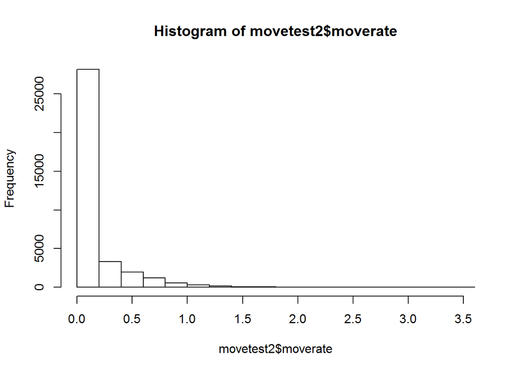

```r
hist(movetest2$moverate)
```

```r
movetest2$seasTOD<-paste(movetest2$season,movetest2$DayPeriod,sep="_")

mod<-lm(movetest2$moverate~as.factor(movetest2$seasTOD))
summary(mod)
```

```
##
## Call:
## lm(formula = movetest2$moverate ~ as.factor(movetest2$seasTOD))
##
## Residuals:
##     Min      1Q  Median      3Q     Max
## -0.2049 -0.1344 -0.0979  0.0162  3.2645
##
## Coefficients:
##                                                 Estimate Std. Error
## (Intercept)                                     0.074451   0.013168
## as.factor(movetest2$seasTOD)Spring_Day          0.004986   0.016015
## as.factor(movetest2$seasTOD)Spring_Night       -0.003834   0.017993
## as.factor(movetest2$seasTOD)Summer_Crepuscular  0.130434   0.013608
## as.factor(movetest2$seasTOD)Summer_Day          0.069036   0.013409
## as.factor(movetest2$seasTOD)Summer_Night        0.029295   0.013433
## as.factor(movetest2$seasTOD)Winter_Crepuscular  0.091925   0.014248
## as.factor(movetest2$seasTOD)Winter_Day          0.076486   0.014015
## as.factor(movetest2$seasTOD)Winter_Night        0.037503   0.013579
##                                                t value Pr(>|t|)
## (Intercept)                                      5.654 1.58e-08 ***
## as.factor(movetest2$seasTOD)Spring_Day           0.311  0.75554
## as.factor(movetest2$seasTOD)Spring_Night        -0.213  0.83126
## as.factor(movetest2$seasTOD)Summer_Crepuscular   9.585  < 2e-16 ***
## as.factor(movetest2$seasTOD)Summer_Day           5.148 2.64e-07 ***
## as.factor(movetest2$seasTOD)Summer_Night         2.181  0.02920 *
## as.factor(movetest2$seasTOD)Winter_Crepuscular   6.452 1.12e-10 ***
## as.factor(movetest2$seasTOD)Winter_Day           5.458 4.86e-08 ***
## as.factor(movetest2$seasTOD)Winter_Night         2.762  0.00575 **
## ---
## Signif. codes:  0 '***' 0.001 '**' 0.01 '*' 0.05 '.' 0.1 ' ' 1
##
## Residual standard error: 0.2495 on 35779 degrees of freedom
## Multiple R-squared:  0.02029,    Adjusted R-squared:  0.02007
## F-statistic:  92.6 on 8 and 35779 DF,  p-value: < 2.2e-16
```

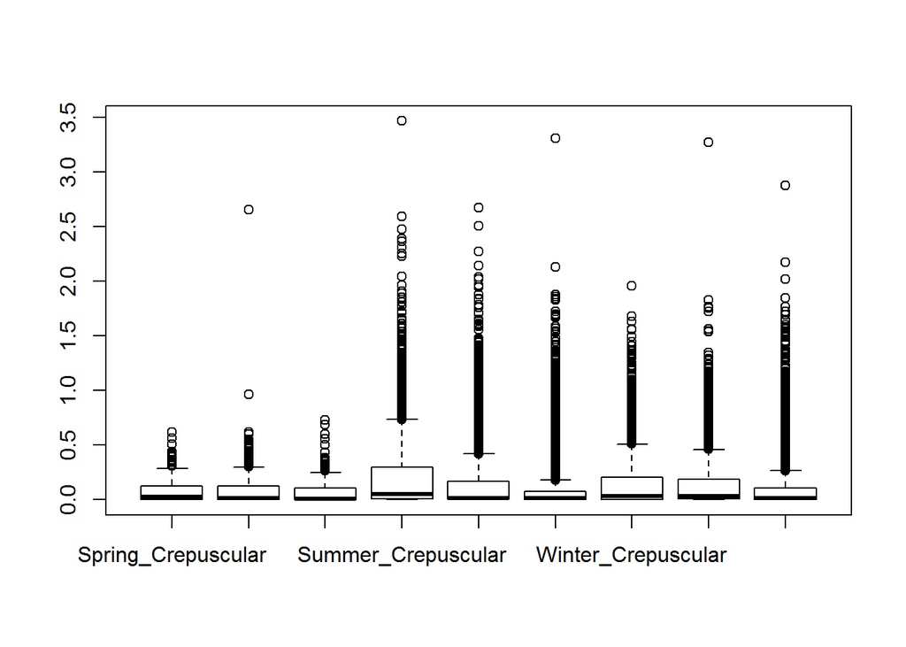

```r
boxplot(movetest2$moverate~as.factor(movetest2$seasTOD))
```

```r
move1<-lme(moverate~as.factor(seasTOD), data=movetest2, random=~1|WOLFID)
summary(move1)
```

```
## Linear mixed-effects model fit by REML
##  Data: movetest2
##        AIC      BIC    logLik
##   818.4388 911.7751 -398.2194
##
## Random effects:
##  Formula: ~1 | WOLFID
##         (Intercept)  Residual
## StdDev:  0.07062004 0.2441884
##
## Fixed effects: moverate ~ as.factor(seasTOD)
##                                            Value  Std.Error    DF
## (Intercept)                           0.10077251 0.02071643 35759
## as.factor(seasTOD)Spring_Day          0.00514534 0.01569249 35759
## as.factor(seasTOD)Spring_Night       -0.00012912 0.01762669 35759
## as.factor(seasTOD)Summer_Crepuscular  0.06341605 0.01364323 35759
## as.factor(seasTOD)Summer_Day          0.00107867 0.01344462 35759
## as.factor(seasTOD)Summer_Night       -0.04594913 0.01347537 35759
## as.factor(seasTOD)Winter_Crepuscular  0.05504453 0.01415302 35759
## as.factor(seasTOD)Winter_Day          0.04393442 0.01389178 35759
## as.factor(seasTOD)Winter_Night       -0.01364918 0.01351008 35759
##                                        t-value p-value
## (Intercept)                           4.864377  0.0000
## as.factor(seasTOD)Spring_Day          0.327886  0.7430
## as.factor(seasTOD)Spring_Night       -0.007325  0.9942
## as.factor(seasTOD)Summer_Crepuscular  4.648172  0.0000
## as.factor(seasTOD)Summer_Day          0.080231  0.9361
## as.factor(seasTOD)Summer_Night       -3.409861  0.0007
## as.factor(seasTOD)Winter_Crepuscular  3.889243  0.0001
## as.factor(seasTOD)Winter_Day          3.162620  0.0016
## as.factor(seasTOD)Winter_Night       -1.010296  0.3124
##  Correlation:
##                                      (Intr) as.fctr(ssTOD)Sp_D
## as.factor(seasTOD)Spring_Day         -0.514
## as.factor(seasTOD)Spring_Night       -0.455  0.602
## as.factor(seasTOD)Summer_Crepuscular -0.614  0.778
## as.factor(seasTOD)Summer_Day         -0.620  0.789
## as.factor(seasTOD)Summer_Night       -0.620  0.787
## as.factor(seasTOD)Winter_Crepuscular -0.586  0.750
## as.factor(seasTOD)Winter_Day         -0.597  0.765
```

[output cut: 20 more lines]

```
## as.factor(seasTOD)Spring_Day
## as.factor(seasTOD)Spring_Night
## as.factor(seasTOD)Summer_Crepuscular
## as.factor(seasTOD)Summer_Day
## as.factor(seasTOD)Summer_Night
## as.factor(seasTOD)Winter_Crepuscular
## as.factor(seasTOD)Winter_Day          0.871
## as.factor(seasTOD)Winter_Night        0.897      0.911
##
## Standardized Within-Group Residuals:
##        Min         Q1        Med         Q3        Max
## -1.4680262 -0.5570199 -0.3335903  0.1713005 13.1973709
##
## Number of Observations: 35788
## Number of Groups: 21
```

```r
###results show that for summer and winter move rates highest in crep, then day, then slowest at night
###releveling to look at spring better
movetest2$seasTOD<-as.factor(movetest2$seasTOD)
movetest2$seasTOD <- relevel(movetest2$seasTOD, ref = "Winter_Day")

move2<-lme(moverate~as.factor(seasTOD), data=movetest2, random=~1|WOLFID)
summary(move2)
```

```
## Linear mixed-effects model fit by REML
##  Data: movetest2
##        AIC      BIC    logLik
##   818.4388 911.7751 -398.2194
##
## Random effects:
##  Formula: ~1 | WOLFID
##         (Intercept)  Residual
## StdDev:  0.07062004 0.2441884
##
## Fixed effects: moverate ~ as.factor(seasTOD)
##                                            Value   Std.Error    DF
## (Intercept)                           0.14470693 0.016682646 35759
## as.factor(seasTOD)Spring_Crepuscular -0.04393442 0.013891778 35759
## as.factor(seasTOD)Spring_Day         -0.03878908 0.010285534 35759
## as.factor(seasTOD)Spring_Night       -0.04406354 0.013076673 35759
## as.factor(seasTOD)Summer_Crepuscular  0.01948163 0.006020356 35759
## as.factor(seasTOD)Summer_Day         -0.04285575 0.005565244 35759
## as.factor(seasTOD)Summer_Night       -0.08988355 0.005615250 35759
## as.factor(seasTOD)Winter_Crepuscular  0.01111011 0.007139851 35759
## as.factor(seasTOD)Winter_Night       -0.05758360 0.005790955 35759
##                                         t-value p-value
## (Intercept)                            8.674100  0.0000
## as.factor(seasTOD)Spring_Crepuscular  -3.162620  0.0016
## as.factor(seasTOD)Spring_Day          -3.771226  0.0002
## as.factor(seasTOD)Spring_Night        -3.369629  0.0008
## as.factor(seasTOD)Summer_Crepuscular   3.235960  0.0012
## as.factor(seasTOD)Summer_Day          -7.700606  0.0000
## as.factor(seasTOD)Summer_Night       -16.007045  0.0000
## as.factor(seasTOD)Winter_Crepuscular   1.556070  0.1197
## as.factor(seasTOD)Winter_Night        -9.943714  0.0000
##  Correlation:
##                                      (Intr) as.fctr(ssTOD)Sp_C
## as.factor(seasTOD)Spring_Crepuscular -0.091
## as.factor(seasTOD)Spring_Day         -0.125  0.184
## as.factor(seasTOD)Spring_Night       -0.095  0.147
## as.factor(seasTOD)Summer_Crepuscular -0.230  0.258
## as.factor(seasTOD)Summer_Day         -0.242  0.279
## as.factor(seasTOD)Summer_Night       -0.241  0.275
## as.factor(seasTOD)Winter_Crepuscular -0.182  0.220
```

[output cut: 20 more lines]

```
## as.factor(seasTOD)Spring_Crepuscular
## as.factor(seasTOD)Spring_Day
## as.factor(seasTOD)Spring_Night
## as.factor(seasTOD)Summer_Crepuscular
## as.factor(seasTOD)Summer_Day
## as.factor(seasTOD)Summer_Night
## as.factor(seasTOD)Winter_Crepuscular  0.560
## as.factor(seasTOD)Winter_Night        0.689              0.539
##
## Standardized Within-Group Residuals:
##        Min         Q1        Med         Q3        Max
## -1.4680262 -0.5570199 -0.3335903  0.1713005 13.1973709
##
## Number of Observations: 35788
## Number of Groups: 21
```

```r
####this shows that for spring wolves moved about the same speed in crep and night and fastest during day but we have much fewer data for spring - spring has by far the least variability among times of day

# move1<-glmer(moverate~as.factor(seasTOD)+(1 |WOLFID ), data=movetest2, family=gaussian())
#   summary(move1)
# ?glmer
```

Here we select a pack-season-TOD and make them the “used” points

```r
table(Wolf1215c_4hr$packIDseasTOD)
```

```
##
##  V003_Spring_Crepuscular          V003_Spring_Day  V003_Summer_Crepuscular
##                        1                       19                       12
##          V003_Summer_Day        V003_Summer_Night  V003_Winter_Crepuscular
##                        9                        3                       26
##          V003_Winter_Day        V003_Winter_Night  V008_Summer_Crepuscular
##                       28                        2                       59
##          V008_Summer_Day        V008_Summer_Night  V008_Winter_Crepuscular
##                      110                      105                       84
##          V008_Winter_Day        V008_Winter_Night  V009_Spring_Crepuscular
##                      148                      314                      166
##          V009_Spring_Day        V009_Spring_Night  V009_Summer_Crepuscular
##                      386                      242                      320
##          V009_Summer_Day        V009_Summer_Night  V009_Winter_Crepuscular
##                      731                      547                      235
##          V009_Winter_Day        V009_Winter_Night  V010_Spring_Crepuscular
##                      583                      942                       93
##          V010_Spring_Day        V010_Spring_Night  V010_Summer_Crepuscular
##                      162                       94                       94
##          V010_Summer_Day        V010_Summer_Night  V010_Winter_Crepuscular
##                      214                      183                      247
##          V010_Winter_Day        V010_Winter_Night  V012_Summer_Crepuscular
##                      190                      380                      269
##          V012_Summer_Day        V012_Summer_Night  V012_Winter_Crepuscular
##                      571                      427                      348
##          V012_Winter_Day        V012_Winter_Night  V013_Summer_Crepuscular
##                      245                      594                       31
##          V013_Summer_Day        V013_Summer_Night  V025_Summer_Crepuscular
##                       38                       26                        1
##          V025_Summer_Day        V025_Summer_Night        V026_Spring_Night
##                        3                        2                       10
##  V026_Summer_Crepuscular          V026_Summer_Day        V026_Summer_Night
##                     1235                     2353                     2319
##  V026_Winter_Crepuscular          V026_Winter_Day        V026_Winter_Night
##                      262                      308                      644
##  V027_Spring_Crepuscular          V027_Spring_Day        V027_Spring_Night
##                       97                      144                       80
##  V027_Summer_Crepuscular          V027_Summer_Day        V027_Summer_Night
##                      195                      309                      284
##  V027_Winter_Crepuscular          V027_Winter_Day        V027_Winter_Night
```

[output cut: 30 more lines]

```
##                       45                       89                      135
##       V0730_Winter_Night V1101_Winter_Crepuscular         V1101_Winter_Day
##                      290                        9                       31
##       V1101_Winter_Night V1102_Summer_Crepuscular         V1102_Summer_Day
##                       43                        1                        3
##       V1102_Summer_Night V1424_Summer_Crepuscular         V1424_Summer_Day
##                        2                      209                      141
##       V1424_Summer_Night V2220_Summer_Crepuscular         V2220_Summer_Day
##                      131                       26                       55
##       V2220_Summer_Night V2901_Summer_Crepuscular         V2901_Summer_Day
##                       26                      142                      121
##       V2901_Summer_Night V2901_Winter_Crepuscular         V2901_Winter_Day
##                       94                       10                        9
##       V2901_Winter_Night
##                       20
```

```r
use<-Wolf1215c_4hr[Wolf1215c_4hr$packIDseasTOD=="V008_Summer_Crepuscular" ,] # sp class
str(use)
```

```
## 'data.frame':    59 obs. of  23 variables:
##  $ OBJECTID     : int  985 988 993 1001 1004 1008 1016 1023 1029 1045 ...
##  $ WOLFID       : chr  "V008" "V008" "V008" "V008" ...
##  $ Latitude     : num  48.3 48.3 48.3 48.3 48.3 ...
##  $ Longitude    : num  -92.6 -92.6 -92.5 -92.6 -92.5 ...
##  $ Altitude     : num  315 324 317 325 335 ...
##  $ dtPm         : POSIXct, format: "2013-07-12 06:00:55" "2013-07-13 06:01:17" ...
##  $ Temp         : int  24 24 22 21 17 11 20 22 17 15 ...
##  $ jul          : chr  "193" "194" "196" "200" ...
##  $ month        : num  7 7 7 7 7 7 7 7 7 8 ...
##  $ DupCheck     : chr  "V00819348.2883008-92.5542912" "V00819448.288249-92.5544063" "V00819648.3064676-92.4996074" "V00820048.289191-92.5517285" ...
##  $ season       : chr  "Summer" "Summer" "Summer" "Summer" ...
##  $ time.diff    : num  21626 43167 21635 21594 43200 ...
##  $ PACKID       : chr  "V008" "V008" "V008" "V008" ...
##  $ packIDseas   : chr  "V008_Summer" "V008_Summer" "V008_Summer" "V008_Summer" ...
##  $ XY           : num [1:59, 1:2] 533062 533054 537105 533252 535801 ...
##  $ Y            : num  5348440 5348435 5350485 5348541 5353702 ...
##  $ X            : num  533062 533054 537105 533252 535801 ...
##  $ EndTimeUTC   : chr  "2013-07-12 11:00:55 GMT" "2013-07-13 11:01:17 GMT" "2013-07-15 11:01:35 GMT" "2013-07-19 11:00:54 GMT" ...
##  $ sunpos       : num  4.68 4.61 4.39 3.73 3.52 ...
##  $ DayPeriod    : chr  "Crepuscular" "Crepuscular" "Crepuscular" "Crepuscular" ...
##  $ packIDseasTOD: chr  "V008_Summer_Crepuscular" "V008_Summer_Crepuscular" "V008_Summer_Crepuscular" "V008_Summer_Crepuscular" ...
##  $ dist         : num  1248.3 16.2 344.3 1537.4 5760 ...
##  $ moverate     : num  0.057723 0.000375 0.015913 0.071197 0.133334 ...
```

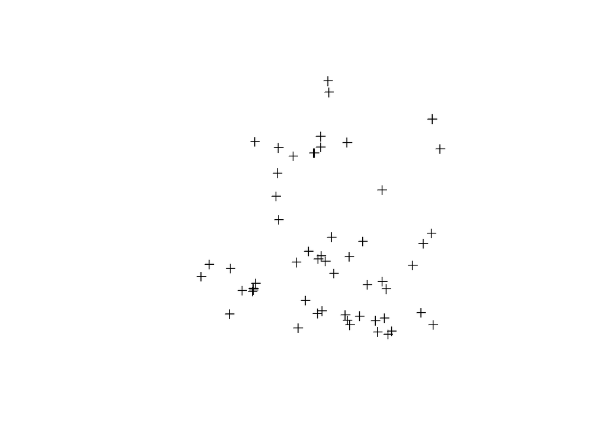

```r
use<-SpatialPoints(use[c("X","Y")])
plot(use)
```

```r
str(use)
```

```
## Formal class 'SpatialPoints' [package "sp"] with 3 slots
##   ..@ coords     : num [1:59, 1:2] 533062 533054 537105 533252 535801 ...
##   .. ..- attr(*, "dimnames")=List of 2
##   .. .. ..$ : chr [1:59] "985" "988" "993" "1001" ...
##   .. .. ..$ : chr [1:2] "X" "Y"
##   ..@ bbox       : num [1:2, 1:2] 528109 5347544 538277 5358343
##   .. ..- attr(*, "dimnames")=List of 2
##   .. .. ..$ : chr [1:2] "X" "Y"
##   .. .. ..$ : chr [1:2] "min" "max"
##   ..@ proj4string:Formal class 'CRS' [package "sp"] with 1 slot
##   .. .. ..@ projargs: chr NA
```

```r
nuse<-nrow(use@coords)
nuse
```

```
## [1] 59
```

Generate some random points from within the `area used by the pack-season One option is to use an overly smoothed KDE of the UD (e.g., using KDE with h = href) to define availability

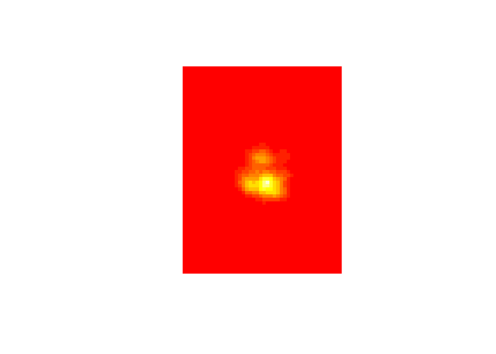

```r
# UD estimate from entire season
HR<-Wolf1215c_4hr[Wolf1215c_4hr$packIDseas=="V008_Summer" ,] # sp class
HR<-SpatialPoints(HR[c("X","Y")])
UD.apollo<-kernelUD(HR, h="href")
image(UD.apollo)
```

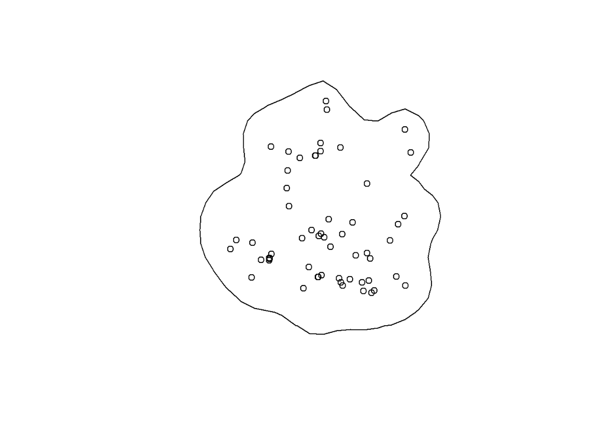

```r
# Outer 95% contour
ver <- getverticeshr(UD.apollo, 95)
plot(ver)
points(use)
```

Generate random points using the csr function in splancs library, but it would be ‘best’ to generate points on a uniform grid.

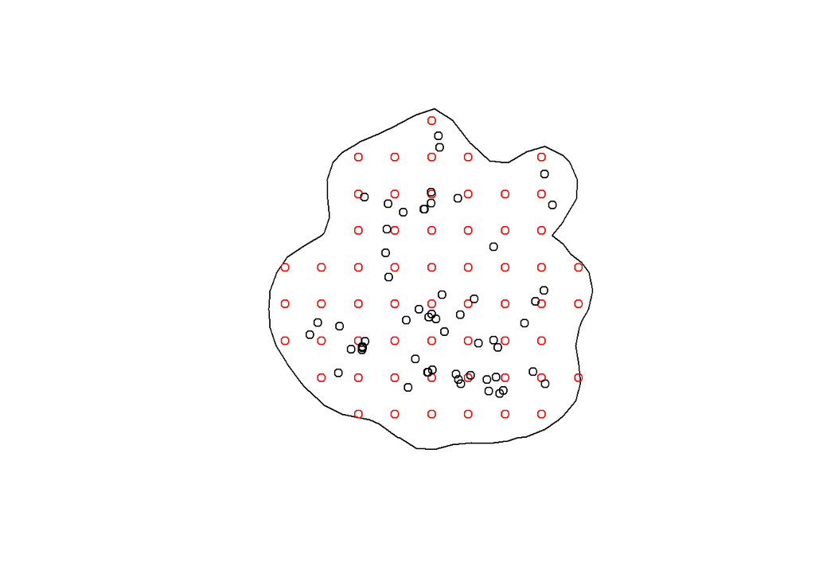

```r
nav<-1 # number of availble points per used point
navail<-nuse*nav
#  avail<-csr(ver@polygons[[1]]@Polygons[[1]]@coords,navail)
avail<-spsample(ver, n=navail, 'regular')
plot(ver)
points(avail, col="red")
points(use)
```

Drop used points that fall outside off the 95% KDE.

```r
kdecontour<-ver@polygons[[1]]@Polygons[[1]]@coords
inkde<-point.in.polygon(use@coords[,1],use@coords[,2], kdecontour[,1], kdecontour[,2])
use<-use[inkde==1,]
```

Read in NLCD (Veg), distance to snowmobile trail, distance to nearest pond/lake We need to extract covariate values for all of the available and used points

```r
avail<-avail@coords
avails<-data.frame(LONG_X=avail[,1], LAT_Y=avail[,2])

vegR<-raster("E:/Moose/Data/OutsideSpatial/NLCD11VNPclip1.tif") #raster: NLCD habitat
nlcdtab<-read.csv("E:/Moose/Data/OutsideSpatial/NLCD11_Table.csv",header=TRUE) #table so you can see what raster value = #list of hab class
#nlcdtab[1:2]

lake30<-raster("E:/Moose/Data/Voyageurs_National_Park/lakedist30")
lakepnd30<-raster("E:/Moose/Data/Voyageurs_National_Park/lakepnddist30")
snowmob<-readOGR("E:/Moose/Data/OutsideSpatial",layer="snowmobile_trails_mn_studyclip") #shapfefiles: snowmobile trails
#convert snowmob to useable psp
snowmob.psp = as.psp(snowmob)
#extract the data from the spatial layers - avail
avails$veg<-extract(vegR, avails[,1:2])
avails$lakedist<-extract(lake30, avails[,1:2])
avails$lakepnddist<-extract(lakepnd30, avails[,1:2])

avails$distsnowmob<-nncross(avail, snowmob.psp)$dist

#extract the data from the spatial layers - used
used<-data.frame(use)
used$veg<-extract(vegR, used[,1:2])
used$lakedist<-extract(lake30, used[,1:2])
used$lakepnddist<-extract(lakepnd30, used[,1:2])


used$distsnowmob<-nncross(used, snowmob.psp)$dist
#use<-used
```

Create the response (y = 0 for available, 1 for used points).

```r
avails$y<-0 # response
# used<-use
used<-used[inkde==1,]
used$y<-1
colnames(used)[1]<-"LONG_X"
colnames(used)[2]<-"LAT_Y"

used<-used[,names(avails)]  # only keep necessary columns...
```

```r
# Merge the use and availability data sets for fitting logistic regression models
# Create weights (weight availability points using a large number)
```

```r
alldat<-rbind(used,avails)
alldat$wt<-1
alldat$wt[alldat$y==0]<-10000
unique(alldat$y)
```

```
## [1] 1 0
```

Create an offset = log(area/$n_a$) so that the intercept in the logistic regression models is comparable to that of the point process model

```r
kde.owin<-owin(poly=list(x=rev(kdecontour[duplicated(kdecontour)!=T,1]), y=rev(kdecontour[duplicated(kdecontour)!=T,2])))
hrarea<-area.owin(kde.owin)
alldat$off<-log(hrarea/navail)
```

Plots to look at distribution of covariates at used and available locations.

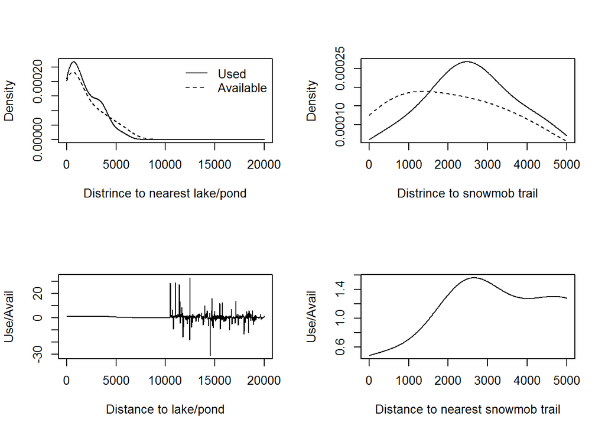

```r
par(mfrow=c(2,2))
uriv<-bkde(used$lakepnddist, range.x=c(0,20000), gridsize=1000)
ariv<-bkde(avails$lakepnddist, range.x=c(0,20000), gridsize=1000)
plot(uriv, type="l", xlab="Distrince to nearest lake/pond", ylab="Density")
lines(ariv, lty=2)
legend("topright", lty=c(1,2), bty="n", c("Used","Available"))
uroad<-bkde(used$distsnowmob, range.x=c(0,5000), gridsize=500)
aroad<-bkde(avails$distsnowmob, range.x=c(0,5000), gridsize=500)
plot(uroad, type="l", xlab="Distrince to snowmob trail", ylab="Density")
lines(aroad, lty=2)
plot(uriv$x, uriv$y/ariv$y, type="l", xlab="Distance to lake/pond", ylab="Use/Avail")
plot(uroad$x, uroad$y/aroad$y, type="l", xlab="Distance to nearest snowmob trail", ylab="Use/Avail")
```

Look at a table of categorical values

```r
par(mfrow=c(1,1))
vegtab<-table(alldat$y, alldat$veg)
prop.table(vegtab,1)
```

```
##
##             11         21         41         42         43         52
##   0 0.22413793 0.00000000 0.17241379 0.20689655 0.15517241 0.01724138
##   1 0.03389831 0.01694915 0.06779661 0.15254237 0.40677966 0.08474576
##
##             90         95
##   0 0.13793103 0.08620690
##   1 0.11864407 0.11864407
```

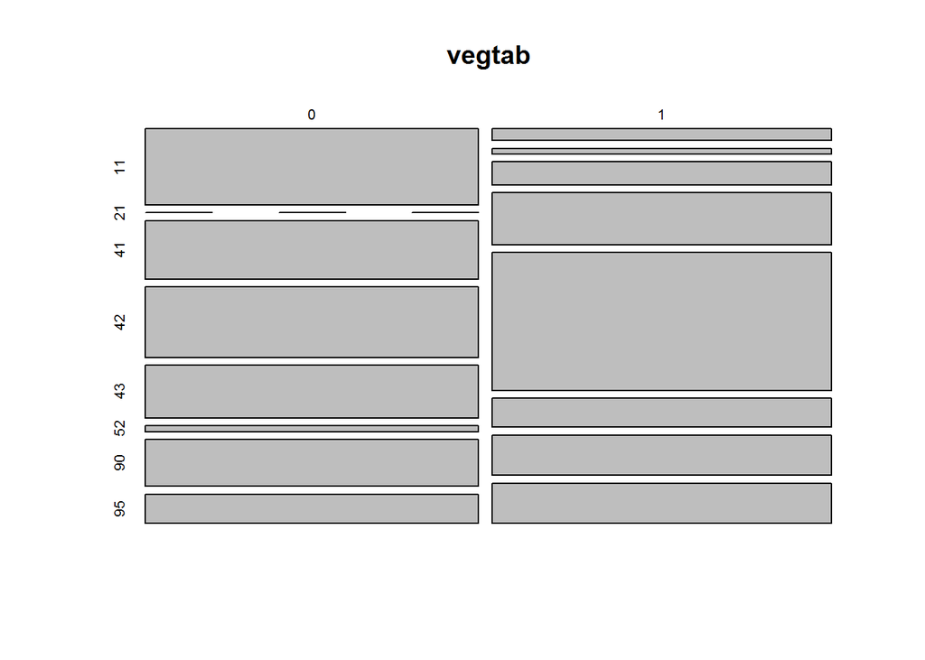

```r
plot(vegtab)
```

```r
nlcdtab[1:2]
```

```
##    Value              Land_Cover_Class
## 1      0                  Unclassified
## 2     11                    Open Water
## 3     21         Developed, Open Space
## 4     22      Developed, Low Intensity
## 5     23   Developed, Medium Intensity
## 6     24     Developed, High Intensity
## 7     31                   Barren Land
## 8     41              Deciduous Forest
## 9     42              Evergreen Forest
## 10    43                  Mixed Forest
## 11    52                   Shrub/Scrub
## 12    71                   Herbaceuous
## 13    81                   Hay/Pasture
## 14    82              Cultivated Crops
## 15    90                Woody Wetlands
## 16    95 Emergent Herbaceuous Wetlands
```

# Fit logistic regression models with and without weights

```r
names(alldat)
```

```
## [1] "LONG_X"      "LAT_Y"       "veg"         "lakedist"    "lakepnddist"
## [6] "distsnowmob" "y"           "wt"          "off"
```

```r
fit1<-glm(y~lakepnddist+distsnowmob+as.factor(veg)+offset(off), data=alldat, family=binomial())
summary(fit1)
```

```
##
## Call:
## glm(formula = y ~ lakepnddist + distsnowmob + as.factor(veg) +
##     offset(off), family = binomial(), data = alldat)
##
## Deviance Residuals:
##      Min        1Q    Median        3Q       Max
## -1.98675  -0.99072   0.00059   0.96310   1.95766
##
## Coefficients:
##                    Estimate Std. Error z value Pr(>|z|)
## (Intercept)      -1.672e+01  8.000e-01 -20.905  < 2e-16 ***
## lakepnddist      -2.135e-04  1.487e-04  -1.436  0.15112
## distsnowmob       1.500e-04  1.587e-04   0.945  0.34456
## as.factor(veg)21  1.809e+01  1.455e+03   0.012  0.99008
## as.factor(veg)41  1.272e+00  9.902e-01   1.284  0.19902
## as.factor(veg)42  1.619e+00  9.458e-01   1.712  0.08685 .
## as.factor(veg)43  2.955e+00  8.804e-01   3.356  0.00079 ***
## as.factor(veg)52  3.859e+00  1.378e+00   2.801  0.00509 **
## as.factor(veg)90  2.073e+00  9.868e-01   2.100  0.03569 *
## as.factor(veg)95  2.306e+00  9.778e-01   2.359  0.01834 *
## ---
## Signif. codes:  0 '***' 0.001 '**' 0.01 '*' 0.05 '.' 0.1 ' ' 1
##
## (Dispersion parameter for binomial family taken to be 1)
##
##     Null deviance: 162.19  on 116  degrees of freedom
## Residual deviance: 136.01  on 107  degrees of freedom
## AIC: 156.01
##
## Number of Fisher Scoring iterations: 14
```

```r
fit1w<-glm(y~lakepnddist+distsnowmob+as.factor(veg)+offset(off), weights=wt,data=alldat, family=binomial())
summary(fit1w)
```

```
##
## Call:
## glm(formula = y ~ lakepnddist + distsnowmob + as.factor(veg) +
##     offset(off), family = binomial(), data = alldat, weights = wt)
##
## Deviance Residuals:
##     Min       1Q   Median       3Q      Max
## -3.1618  -1.1241   0.0016   4.1446   4.6914
##
## Coefficients:
##                    Estimate Std. Error z value Pr(>|z|)
## (Intercept)      -2.630e+01  7.621e-01 -34.504  < 2e-16 ***
## lakepnddist      -2.669e-04  1.072e-04  -2.489  0.01281 *
## distsnowmob       3.688e-04  1.391e-04   2.651  0.00801 **
## as.factor(veg)21  2.537e+01  5.354e+02   0.047  0.96221
## as.factor(veg)41  1.415e+00  8.804e-01   1.607  0.10802
## as.factor(veg)42  1.126e+00  8.248e-01   1.366  0.17207
## as.factor(veg)43  3.073e+00  7.432e-01   4.135 3.55e-05 ***
## as.factor(veg)52  3.667e+00  8.440e-01   4.345 1.39e-05 ***
## as.factor(veg)90  1.527e+00  8.194e-01   1.864  0.06235 .
## as.factor(veg)95  2.093e+00  8.095e-01   2.585  0.00974 **
## ---
## Signif. codes:  0 '***' 0.001 '**' 0.01 '*' 0.05 '.' 0.1 ' ' 1
##
## (Dispersion parameter for binomial family taken to be 1)
##
##     Null deviance: 1202.8  on 116  degrees of freedom
## Residual deviance: 1128.6  on 107  degrees of freedom
## AIC: 1148.6
##
## Number of Fisher Scoring iterations: 12
```

# Fit ppp model using the same use and availability points

```r
used.ppp<-ppp(used[,1], used[,2],window=as.owin(kde.owin))
Q <- quadscheme(data=used.ppp, dummy=list(x=avails[,1], y=avails[,2]))
df <- data.frame(lakepnddist=c(used$lakepnddist, avails$lakepnddist), veg=c(used$veg, avails$veg),
                 distsnowmob=c(used$distsnowmob, avails$distsnowmob))

ppfit<- ppm(Q, ~ distsnowmob+lakepnddist+as.factor(veg), Poisson(), covariates=df)
summary(ppfit)
```

```
## Point process model
## Fitting method: maximum likelihood (Berman-Turner approximation)
## Model was fitted using glm()
## Algorithm converged
## Call:
## ppm.quad(Q = Q, trend = ~distsnowmob + lakepnddist + as.factor(veg),
##     interaction = Poisson(), covariates = df)
## Edge correction: "border"
##  [border correction distance r = 0 ]
## ---------------------------------------------------------------------------
## Quadrature scheme = data + dummy + weights
##
## Data pattern:
## Planar point pattern:  59 points
## Average intensity 4.22e-07 points per square unit
## Window: polygonal boundary
## single connected closed polygon with 76 vertices
## enclosing rectangle: [526380.8, 539952.4] x [5345210, 5359466] units
## Window area = 139906000 square units
##
## Dummy quadrature points:
##      (rule for creating dummy points not understood)
## Planar point pattern:  58 points
## Average intensity 4.15e-07 points per square unit
## Window: polygonal boundary
## single connected closed polygon with 76 vertices
## enclosing rectangle: [526380.8, 539952.4] x [5345210, 5359466] units
## Window area = 139906000 square units
## Quadrature weights:
##      (counting weights based on 5 x 5 array of rectangular tiles)
## All weights:
##  range: [553000, 2530000]    total: 1.38e+08
## Weights on data points:
##  range: [553000, 2440000]    total: 58300000
## Weights on dummy points:
##  range: [553000, 2530000]    total: 79600000
## ---------------------------------------------------------------------------
## FITTED MODEL:
##
## Nonstationary Poisson process
```

[output cut: 44 more lines]

```
## Fitted regular parameters (theta):
##      (Intercept)      distsnowmob      lakepnddist as.factor(veg)21
##    -1.626191e+01     1.486426e-04    -5.711742e-05     2.764967e+00
## as.factor(veg)41 as.factor(veg)42 as.factor(veg)43 as.factor(veg)52
##     9.069175e-01     1.062598e+00     1.566842e+00     1.815090e+00
## as.factor(veg)90 as.factor(veg)95
##     1.189257e+00     1.665784e+00
##
## Fitted exp(theta):
##      (Intercept)      distsnowmob      lakepnddist as.factor(veg)21
##     8.660520e-08     1.000149e+00     9.999429e-01     1.587851e+01
## as.factor(veg)41 as.factor(veg)42 as.factor(veg)43 as.factor(veg)52
##     2.476676e+00     2.893879e+00     4.791493e+00     6.141630e+00
## as.factor(veg)90 as.factor(veg)95
##     3.284638e+00     5.289819e+00
```

Lastly, rsf fit from Lele & Keim

```r
rsffit<-rsf(y~distsnowmob+lakepnddist+as.factor(veg)+offset(off), data=alldat, m=0)
summary(rsffit)
```

```
##
## Call:
## rsf(formula = y ~ distsnowmob + lakepnddist + as.factor(veg) + offset(off),
##     data = alldat, m = 0)
##
## Resource Selection Function (Exponential RSF) model
## Non-matched Used-Available design
## Maximum Likelihood estimates
## with Nonparametric Bootstrap standard errors (B = 99)
##
## Fitted values:
##      Min.   1st Qu.    Median      Mean   3rd Qu.      Max.
## 1.000e+00 4.000e+00 1.100e+01 1.098e+07 2.600e+01 1.284e+09
##
## Coefficients (log link):
##                    Estimate Std. Error z value Pr(>|z|)
## distsnowmob       0.0003252  0.0001953   1.665   0.0959 .
## lakepnddist      -0.0002466  0.0001244  -1.983   0.0474 *
## as.factor(veg)21 21.1780957 24.1984601   0.875   0.3815
## as.factor(veg)41  1.3639766  3.7657455   0.362   0.7172
## as.factor(veg)42  1.1905766  3.7747274   0.315   0.7525
## as.factor(veg)43  2.9895383  3.7375134   0.800   0.4238
## as.factor(veg)52  3.5647788  3.8614611   0.923   0.3559
## as.factor(veg)90  1.5629024  3.8153595   0.410   0.6821
## as.factor(veg)95  2.0918340  3.8197831   0.548   0.5839
## ---
## Signif. codes:  0 '***' 0.001 '**' 0.01 '*' 0.05 '.' 0.1 ' ' 1
##
## Log-likelihood: -210.1
## BIC = 456.9
##
## Hosmer and Lemeshow goodness of fit (GOF) test:
## X-squared = 10.01, df = 8, p-value 0.2642
```

```r
nlcdtab[1:2]
```

```
##    Value              Land_Cover_Class
## 1      0                  Unclassified
## 2     11                    Open Water
## 3     21         Developed, Open Space
## 4     22      Developed, Low Intensity
## 5     23   Developed, Medium Intensity
## 6     24     Developed, High Intensity
## 7     31                   Barren Land
## 8     41              Deciduous Forest
## 9     42              Evergreen Forest
## 10    43                  Mixed Forest
## 11    52                   Shrub/Scrub
## 12    71                   Herbaceuous
## 13    81                   Hay/Pasture
## 14    82              Cultivated Crops
## 15    90                Woody Wetlands
## 16    95 Emergent Herbaceuous Wetlands
```

```r
unique(alldat$veg)
```

```
## [1] 95 43 21 42 41 52 90 11
```

```r
# coef(rsffit)
# rsffit$std.error[1]
# cfH<-data.frame(summary(rsffit)$Std.Error)
```

# Now, compare the coefficients from the different fitted models

```r
coefs<-cbind(coef(fit1), coef(fit1w), coef(ppfit), c(NA,coef(rsffit)))
colnames(coefs)<-c("LR no wts", "LR wt", "PPM", "rsf")
rownames(coefs)<-names(coef(fit1))
outcoefs<-print(format(coefs,digits=3, scientific=T), quote=F)
```

```
##                  LR no wts LR wt     PPM       rsf
## (Intercept)      -1.67e+01 -2.63e+01 -1.63e+01        NA
## lakepnddist      -2.13e-04 -2.67e-04  1.49e-04  3.25e-04
## distsnowmob       1.50e-04  3.69e-04 -5.71e-05 -2.47e-04
## as.factor(veg)21  1.81e+01  2.54e+01  2.76e+00  2.12e+01
## as.factor(veg)41  1.27e+00  1.41e+00  9.07e-01  1.36e+00
## as.factor(veg)42  1.62e+00  1.13e+00  1.06e+00  1.19e+00
## as.factor(veg)43  2.96e+00  3.07e+00  1.57e+00  2.99e+00
## as.factor(veg)52  3.86e+00  3.67e+00  1.82e+00  3.56e+00
## as.factor(veg)90  2.07e+00  1.53e+00  1.19e+00  1.56e+00
## as.factor(veg)95  2.31e+00  2.09e+00  1.67e+00  2.09e+00
```

# Possible diagnostics using output of ppm model

Some diagnostic plots

```r
 diagnose.ppm(ppfit)
```

[figure not shown]

```
## Model diagnostics (raw residuals)
## Diagnostics available:
##  four-panel plot
##  mark plot
##  smoothed residual field
##  x cumulative residuals
##  y cumulative residuals
##  sum of all residuals
## sum of raw residuals in entire window = -1.084e-12
## area of entire window = 139900000
## quadrature area = 137900000
## range of smoothed field =  [-2.151e-07, 3.709e-07]
```

```r
# te<-quadrat.test(ppfit)
# te
# plot(te)
```